# Reproducible Research: Peer Assessment 1

## What is the average daily activity pattern?

1. Making a time series plot (i.e. type = “l”) of the 5-minute interval (x-axis) and the average number of steps taken, averaged across all days (y-axis)

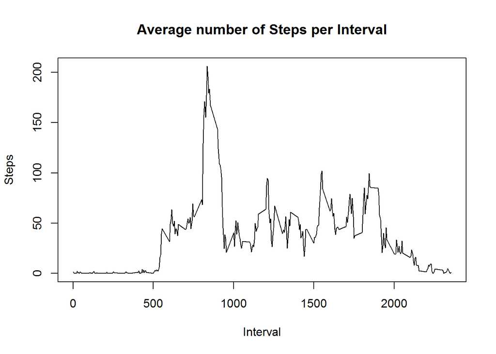

```r
library(ggplot2)
intervalData <- ddply(activity, c("interval"), summarize, steps = mean(steps, na.rm = T))
colnames(intervalData) <- c("Interval", "Steps")
plot(intervalData, type = "l", main="Average number of Steps per Interval")
```

2. The 5-minute interval, on average across all the days in the dataset, containing the maximum number of steps is:

```r
intervalData$Interval[which.max(intervalData$Steps)]
```

```
## [1] 835
```

## Imputing missing values

1. Total number of rows with NAs  
   Note that there are a number of days/intervals where there are missing values (coded as NA). The presence of missing days may introduce bias into some calculations or summaries of the data.

```r
nrow(activity[is.na(activity$steps),])
```

```
## [1] 2304
```

```r
summary(activity$steps)
```

```
##    Min. 1st Qu.  Median    Mean 3rd Qu.    Max.    NA's
##     0.0     0.0     0.0    37.4    12.0   806.0    2304
```

```r
mean(activity$steps, na.rm = TRUE)
```

```
## [1] 37.38
```

```r
sd(activity$steps, na.rm = TRUE)
```

```
## [1] 112
```

Devise a strategy for filling in all of the missing values in the dataset.  
2. Use the mean for 5-minute interval, to replace the missing values. *We will use the means of same interval as the one missing to fill in its missing values.*  
Other alternatives were examined and can equaly be used as well with similar corrective results Such as a random number genrator with same mean and sd, or same day of the week average, or average of same interval of the missing value. The average of the same interval as the missing values appears to be the most effective due to habits, although something can be said if weekday or weekend are actored into it.

3. A new dataset that is equal to the original dataset but with the missing data filled in.

```r
activity.filled <- activity
for (i in seq(nrow(activity))) {
    if (is.na(activity$steps[i])) {
        activity.filled$steps[i] <-  intervalData$Steps [intervalData$Interval == activity$interval[i]]
    }
}
```

4. Histogram of the total number of steps taken each day (Filled Data)

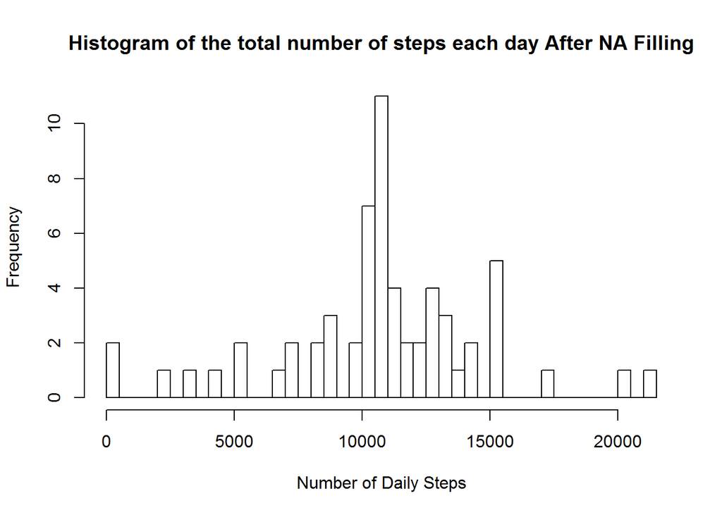

```r
library(lattice)
# This code was used for debugging purposes to further digg deeper into the data

# xyplot(steps ~ interval | date, data = aggregate(steps ~ interval + date,
#         activity, FUN = sum),
#        type = "l",
#        layout = c(7, 9),
#        group=date,
#        ylab = "Total Daily Steps",
#        xlab = "Date")


## Display the daily plot After fillings are made

dailyData <- ddply(activity.filled, c("Date"), summarize, dailysteps = sum(steps))
hist(dailyData$dailysteps, breaks = 62, main = "Histogram of the total number of steps each day After NA Filling", xlab = "Number of Daily Steps")
```

```r
## Mean and Median of the complete Filled Activities
mean(tapply(activity.filled$steps, activity.filled$date, sum, na.rm = TRUE))
```

```
## [1] 10766
```

```r
median(tapply(activity.filled$steps, activity.filled$date, sum, na.rm = TRUE))
```

```
## [1] 10766
```

```r
message("The mean and median results are alligned and demonstrate the elimination of bias resulting fom the NA values in the dataset. The graph shows the improved concentration around the mean as well as increase in the Frequency around it, since the NAs have been filled, Thus an increace in the Mean and allignment between the Mean and the Median.")
```

[output not shown]

```r
head(activity.filled)
```

```
##     steps       date interval       Date dayname
## 1 1.71698 2012-10-01        0 2012-10-01  Monday
## 2 0.33962 2012-10-01        5 2012-10-01  Monday
## 3 0.13208 2012-10-01       10 2012-10-01  Monday
## 4 0.15094 2012-10-01       15 2012-10-01  Monday
## 5 0.07547 2012-10-01       20 2012-10-01  Monday
## 6 2.09434 2012-10-01       25 2012-10-01  Monday
```

```r
tail(activity.filled)
```

```
##        steps       date interval       Date dayname
## 17563 2.6038 2012-11-30     2330 2012-11-30  Friday
## 17564 4.6981 2012-11-30     2335 2012-11-30  Friday
## 17565 3.3019 2012-11-30     2340 2012-11-30  Friday
## 17566 0.6415 2012-11-30     2345 2012-11-30  Friday
## 17567 0.2264 2012-11-30     2350 2012-11-30  Friday
## 17568 1.0755 2012-11-30     2355 2012-11-30  Friday
```

```r
summary(activity.filled)
```

```
##      steps            date               interval
##  Min.   :  0.0   Min.   :2012-10-01   Min.   :   0
##  1st Qu.:  0.0   1st Qu.:2012-10-16   1st Qu.: 589
##  Median :  0.0   Median :2012-10-31   Median :1178
##  Mean   : 37.4   Mean   :2012-10-31   Mean   :1178
##  3rd Qu.: 27.0   3rd Qu.:2012-11-15   3rd Qu.:1766
##  Max.   :806.0   Max.   :2012-11-30   Max.   :2355
##
##       Date                          dayname
##  Min.   :2012-10-01 00:00:00   Friday   :2592
##  1st Qu.:2012-10-16 00:00:00   Monday   :2592
##  Median :2012-10-31 00:00:00   Saturday :2304
##  Mean   :2012-10-31 00:25:34   Sunday   :2304
##  3rd Qu.:2012-11-15 00:00:00   Thursday :2592
##  Max.   :2012-11-30 00:00:00   Tuesday  :2592
##                                Wednesday:2592
```

```r
str(activity.filled)
```

```
## 'data.frame':    17568 obs. of  5 variables:
##  $ steps   : num  1.717 0.3396 0.1321 0.1509 0.0755 ...
##  $ date    : Date, format: "2012-10-01" "2012-10-01" ...
##  $ interval: num  0 5 10 15 20 25 30 35 40 45 ...
##  $ Date    : POSIXlt, format: "2012-10-01" "2012-10-01" ...
##  $ dayname : Factor w/ 7 levels "Friday","Monday",..: 2 2 2 2 2 2 2 2 2 2 ...
```

## Are there differences in activity patterns between weekdays and weekends?

1. Create a new factor variable in the dataset with two levels - “weekday” and “weekend” indicating whether a given date is a weekday or weekend day.

```r
activity.filled$day <- as.factor(ifelse(weekdays(activity.filled$date)
                                 %in% c("Saturday","Sunday"),
                                 "Weekend", "Weekday"))
```

2. Make a panel plot containing a time series plot (i.e. type = “l”) of the 5-minute interval (x-axis) and the average number of steps taken, averaged across all weekday days or weekend days (y-axis).

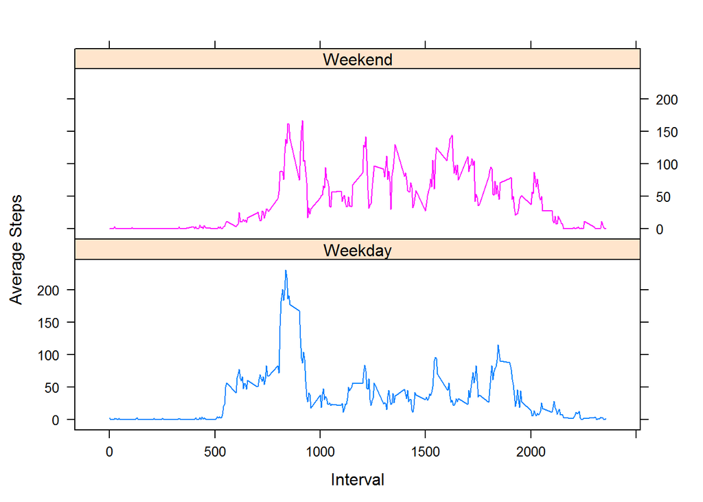

```r
library(lattice)
xyplot(steps ~ interval | day, data = aggregate(steps ~ interval + day,
                                                activity.filled, FUN = mean),
       layout = c(1, 2), type = "l", group=day, ylab = "Average Steps",
       xlab = "Interval")
```

```r
weekData <- ddply(activity.filled, .(day, interval), summarize, dailysteps = mean(steps))
weekdays <- weekData[weekData$day == "Weekday", ]
weekends <- weekData[weekData$day == "Weekend", ]
#t.test()
summary(weekdays)
```

```
##       day         interval      dailysteps
##  Weekday:288   Min.   :   0   Min.   :  0.00
##  Weekend:  0   1st Qu.: 589   1st Qu.:  2.25
##                Median :1178   Median : 25.80
##                Mean   :1178   Mean   : 35.61
##                3rd Qu.:1766   3rd Qu.: 50.85
##                Max.   :2355   Max.   :230.38
```

```r
summary(weekends)
```

```
##       day         interval      dailysteps
##  Weekday:  0   Min.   :   0   Min.   :  0.00
##  Weekend:288   1st Qu.: 589   1st Qu.:  1.24
##                Median :1178   Median : 32.34
##                Mean   :1178   Mean   : 42.37
##                3rd Qu.:1766   3rd Qu.: 74.65
##                Max.   :2355   Max.   :166.64
```

```r
message("Yes there are differences between the Weekdays and Weekends, as demonstrated in the Plot and Summary printout. These differences do support the earlier conclusion of additional value in selecting Weekday Interval Average to fill missing values falling within the same parameters. However, since the median and mean coalessed, significant benefit would be immaterial from such a use")
```

[output not shown]